# Annotated Heatmaps

## Description

The function `aheatmap` plots high-quality heatmaps, with a detailed legend and unlimited annotation tracks for both columns and rows. The annotations are coloured differently according to their type (factor or numeric covariate). Although it uses grid graphics, the generated plot is compatible with base layouts such as the ones defined with `'mfrow'` or `layout`, enabling the easy drawing of multiple heatmaps on a single a plot -- at last!.

## Usage

```
aheatmap(x, color = "-RdYlBu2:100", na.color = NA, type = c("rect", "circle", "roundrect"),
  breaks = NA, border_color = NA, cellwidth = NA, cellheight = NA, scale = "none",
      Rowv = TRUE, Colv = TRUE, revC = identical(Colv, "Rowv") || is_NA(Rowv) || (is.integer(Rowv) &&
          length(Rowv) > 1) || is(Rowv, "silhouette"), distfun = "euclidean", hclustfun = "complete",
      reorderfun = function(d, w) reorder(d, w), treeheight = 50, legend = TRUE, annCol = NA,
      annRow = NA, annColors = NA, annLegend = TRUE, cexAnn = NA, labRow = NULL, labCol = NULL,
      subsetRow = NULL, subsetCol = NULL, txt = NULL, layout = ".", fontsize = 10,
      cexRow = min(0.2 + 1/log10(nr), 1.2), cexCol = min(0.2 + 1/log10(nc), 1.2), filename = NA,
      width = NA, height = NA, main = NULL, sub = NULL, info = NULL, verbose = getOption("verbose"),
      trace = verbose > 1, gp = gpar())
```

## Arguments

**x**

numeric matrix of the values to be plotted. An `ExpressionSet` objects can also be passed, in which case the expression values are plotted (`exprs(x)`).

**color**

colour specification for the heatmap. Default to palette '-RdYlBu2:100', i.e. reversed palette 'RdYlBu2' (a slight modification of RColorBrewer's palette 'RdYlBu') with 100 colors. Possible values are:

- a character/integer vector of length greater than 1 that is directly used and assumed to contain valid R color specifications.
- a single color/integer (between 0 and 8)/other numeric value that gives the dominant colors. Numeric values are converted into a pallete by `rev(sequential_hcl(2, h = x, l = c(50, 95)))`. Other values are concatenated with the grey colour '#F1F1F1'.
- one of RColorBrewer's palette name (see `display.brewer.all`) , or one of 'RdYlBu2', 'rainbow', 'heat', 'topo', 'terrain', 'cm'.

When the coluor palette is specified with a single value, and is negative or preceded a minus ('-'), the reversed palette is used. The number of breaks can also be specified after a colon (':'). For example, the default colour palette is specified as '-RdYlBu2:100'.

**na.color**

Specifies the colour to use for `NA` values. Setting to `NA` (default) produces uncoloured cells (white). It can also be a list of 2 elements, with the first element specifying the color and the second a given value or a range of values (as a 2-length vector) to be forced to NA.

**type**

type of cell shapes (still experimental feature).

**breaks**

a sequence of numbers that covers the range of values in `x` and is one element longer than color vector. Used for mapping values to colors. Useful, if needed to map certain values to certain colors. If NA then the breaks are calculated automatically. If `breaks` is a single value, then the colour palette is forced to be centered on this value.

**border_color**

color of cell borders on heatmap, use NA if no border should be drawn. This argument allows for a finer control of borders (see dedicated demos and vignettes).

**cellwidth**

individual cell width in points. If left as NA, then the values depend on the size of plotting window.

**cellheight**

individual cell height in points. If left as NA, then the values depend on the size of plotting window.

**scale**

character indicating how the values should scaled in either the row direction or the column direction. Note that the scaling is performed after row/column clustering, so that it has no effect on the row/column ordering. Possible values are:

- `"row"`: center and standardize each row separately to row Z-scores
- `"column"`: center and standardize each column separately to column Z-scores
- `"r1"`: scale each row to sum up to one
- `"c1"`: scale each column to sum up to one
- `"none"`: no scaling

**Rowv**

clustering specification(s) for the rows. It allows to specify the distance/clustering/ordering/display parameters to be used for the *rows only*. See section *Row/column ordering and display* for details on all supported values.

**Colv**

clustering specification(s) for the columns. It accepts the same values as argument `Rowv` (modulo the expected length for vector specifications), and allow specifying the distance/clustering/ordering/display parameters to be used for the *columns only*. `Colv` may also be set to `"Rowv"`, in which case the dendrogram or ordering specifications applied to the rows are also applied to the columns. Note that this is allowed only for square matrices, and that the row ordering is in this case by default reversed (`revC=TRUE`) to obtain the diagonal in the standard way (from top-left to bottom-right). See section *Row/column ordering and display* for details on all supported values.

**revC**

a logical that specify if the *row order* defined by `Rowv` should be reversed. This is mainly used to get the rows displayed from top to bottom, which is not the case by default. Its default value is computed at runtime, to suit common situations where natural ordering is a more sensible choice: no or fix ordering of the rows (`Rowv=NA` or an integer vector of indexes -- of length > 1), and when a symmetric ordering is requested -- so that the diagonal is shown as expected. An argument in favor of the "odd" default display (bottom to top) is that the row dendrogram is plotted from bottom to top, and reversing its reorder may take a not too long but non negligeable time.

**distfun**

default distance measure used in clustering rows and columns. Possible values are:

- all the distance methods supported by `dist` (e.g. "euclidean" or "maximum").
- all correlation methods supported by `cor`, such as `"pearson"` or `"spearman"`. The pairwise distances between rows/columns are then computed as `d <- dist(1 - cor(..., method = distfun))`. One may as well use the string "correlation" which is an alias for "pearson".
- an object of class `dist` such as returned by `dist` or `as.dist`.

**hclustfun**

default clustering method used to cluster rows and columns. Possible values are:

- a method name (a character string) supported by `hclust` (e.g. `'average'`).
- an object of class `hclust` such as returned by `hclust`
- a dendrogram

**reorderfun**

default dendrogram reordering function, used to reorder the dendrogram, when either `Rowv` or `Colv` is a numeric weight vector, or provides or computes a dendrogram. It must take 2 parameters: a dendrogram, and a weight vector.

**subsetRow**

Specification of subsetting the rows before drawing the heatmap. Possible values are:

- an integer vector of length > 1 specifying the indexes of the rows to keep;
- a character vector of length > 1 specyfing the names of the rows to keep. These are the original rownames, not the names specified in `labRow`.
- a logical vector of length > 1, whose elements are recycled if the vector has not as many elements as rows in `x`.

Note that in the case `Rowv` is a dendrogram or hclust object, it is first converted into an ordering vector, and cannot be displayed -- and a warning is thrown.

**subsetCol**

Specification of subsetting the columns before drawing the heatmap. It accepts the similar values as `subsetRow`. See details above.

**txt**

character matrix of the same size as `x`, that contains text to display in each cell. `NA` values are allowed and are not displayed. See demo for an example.

**treeheight**

how much space (in points) should be used to display dendrograms. If specified as a single value, it is used for both dendrograms. A length-2 vector specifies separate values for the row and column dendrogram respectively. Default value: 50 points.

**legend**

boolean value that determines if a colour ramp for the heatmap's colour palette should be drawn or not. Default is `TRUE`.

**annRow**

specifications of row annotation tracks displayed as coloured columns on the left of the heatmaps. The annotation tracks are drawn from left to right. The same conversion, renaming and colouring rules as for argument `annCol` apply.

**annColors**

list for specifying annotation track colors manually. It is possible to define the colors for only some of the annotations. Check examples for details.

**annLegend**

boolean value specifying if the legend for the annotation tracks should be drawn or not. Default is `TRUE`.

**cexAnn**

scaling coefficent for the size of the annotation tracks. Values > 1 (resp. < 1) will increase (resp. decrease) the size of each annotation track. This applies to the height (resp. width) of the column (resp. row) annotation tracks. Separate row and column sizes can be specified as a vector `c(row_size, col_size)`, where an NA value means using the default for the corresponding track.

**labRow**

labels for the rows.

**layout**

layout specification that indicates the relative position of the heatmap's components. Two layouts can be defined: one horizontal, which relates to components associated to rows, and one vertical, which relates to components associated with columns. Each layout is specified as a character strings, composed of characters that encode the order of each component: dendrogram (d), annotation tracks (a), data matrix (m), labels (l) and legend (L). See `aheatmap_layout` for more details on layout specifications.

**fontsize**

base fontsize for the plot

**cexRow**

fontsize for the rownames, specified as a fraction of argument `fontsize`.

**cexCol**

fontsize for the colnames, specified as a fraction of argument `fontsize`.

**main**

Main title as a character string or a grob.

**sub**

Subtitle as a character string or a grob.

**info**

(experimental) Extra information as a character vector or a grob. If `info=TRUE`, information about the clustering methods is displayed at the bottom of the plot.

**filename**

file path ending where to save the picture. Currently following formats are supported: png, pdf, tiff, bmp, jpeg. Even if the plot does not fit into the plotting window, the file size is calculated so that the plot would fit there, unless specified otherwise.

**height**

manual option for determining the output file height in inches.

**verbose**

if `TRUE` then verbose messages are displayed and the borders of some viewports are highlighted. It is entended for debugging purposes.

**trace**

logical that indicates if the different grid viewports should be traced with a blue border (debugging purpose).

**gp**

graphical parameters for the text used in plot. Parameters passed to `grid.text`, see `gpar`.

## Details

The development of this function started as a fork of the function `pheatmap` from the pheatmap package, and provides several enhancements such as:

- argument names match those used in the base function `heatmap`;
- unlimited number of annotation for **both** columns and rows, with simplified and more flexible interface;
- easy specification of clustering methods and colors;
- return clustering data, as well as grid grob object.

Please read the associated vignette for more information and sample code.

## PDF graphic devices

if plotting on a PDF graphic device -- started with `pdf`, one may get generate a first blank page, due to internals of standard functions from the grid package that are called by `aheatmap`. The NMF package ships a custom patch that fixes this issue. However, in order to comply with CRAN policies, the patch is **not** applied by default and the user must explicitly be enabled it. This can be achieved on runtime by either setting the NMF specific option 'grid.patch' via `nmf.options(grid.patch=TRUE)`, or on load time if the environment variable 'R_PACKAGE_NMF_GRID_PATCH' is defined and its value is something that is not equivalent to `FALSE` (i.e. not '', 'false' nor 0).

## Row/column ordering and display

Possible values are:

- `TRUE` or `NULL` (to be consistent with `heatmap`): compute a dendrogram from hierarchical clustering using the distance and clustering methods `distfun` and `hclustfun`.
- `NA`: disable any ordering. In this case, and if not otherwise specified with argument `revC=FALSE`, the heatmap shows the input matrix with the rows in their original order, with the first row on top to the last row at the bottom. Note that this differ from the behaviour or `heatmap`, but seemed to be a more sensible choice when vizualizing a matrix without reordering.
- an integer vector of length the number of rows of the input matrix (`nrow(x)`), that specifies the row order. As in the case `Rowv=NA`, the ordered matrix is shown first row on top, last row at the bottom.
- a character vector or a list specifying values to use instead of arguments `distfun`, `hclustfun` and `reorderfun` when clustering the rows (see the respective argument descriptions for a list of accepted values). If `Rowv` has no names, then the first element is used for `distfun`, the second (if present) is used for `hclustfun`, and the third (if present) is used for `reorderfun`.
- a numeric vector of weights, of length the number of rows of the input matrix, used to reorder the internally computed dendrogram `d` by `reorderfun(d, Rowv)`.
- `FALSE`: the dendrogram *is* computed using methods `distfun`, `hclustfun`, and `reorderfun` but is not shown.
- a single integer that specifies how many subtrees (i.e. clusters) should be highlighted, e.g., `aheatmap(x, Rowv = 3L)`.

  If positive, then the dendrogram's branches upstream each cluster are faded out using dashed lines. If negative, then the dendrogram's branches within each cluster are faded out using dashed lines, keeping the root upstream branches as is.
- a single double that specifies how much space is used by the computed dendrogram. That is that this value is used in place of `treeheight`.
- a single character string starting with a `'#'` or a list with its first element as such a string, e.g., `aheatmap(x, Rowv = '#3')` or `aheatmap(x, Colv = list('#3', text = LETTERS[1:3]))`.

## Examples

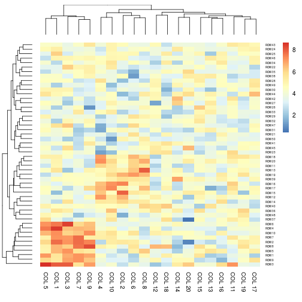

```r
## See the demo 'aheatmap' for more examples:
## Not run:
##D demo('aheatmap')
## End(Not run)

# Generate random data
n <- 50; p <- 20
x <- abs(rmatrix(n, p, rnorm, mean=4, sd=1))
x[1:10, seq(1, 10, 2)] <- x[1:10, seq(1, 10, 2)] + 3
x[11:20, seq(2, 10, 2)] <- x[11:20, seq(2, 10, 2)] + 2
rownames(x) <- paste("ROW", 1:n)
colnames(x) <- paste("COL", 1:p)

## Default heatmap
aheatmap(x)
```

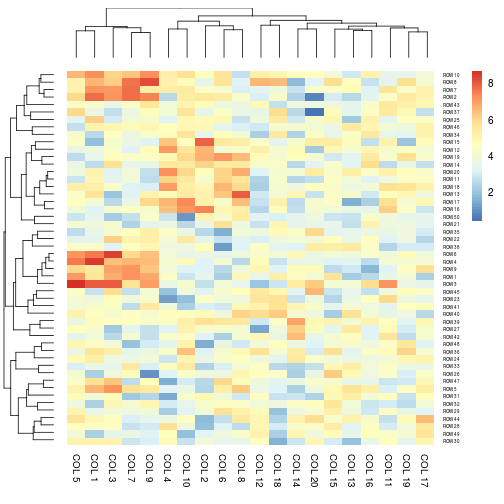

```r
## Distance methods
aheatmap(x, Rowv = "correlation")
```

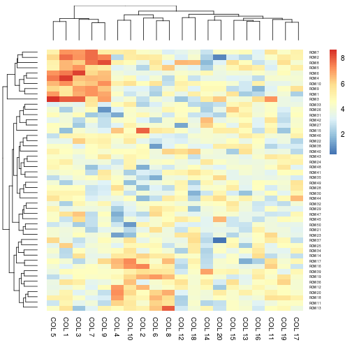

```r
aheatmap(x, Rowv = "man") # partially matched to 'manhattan'
```

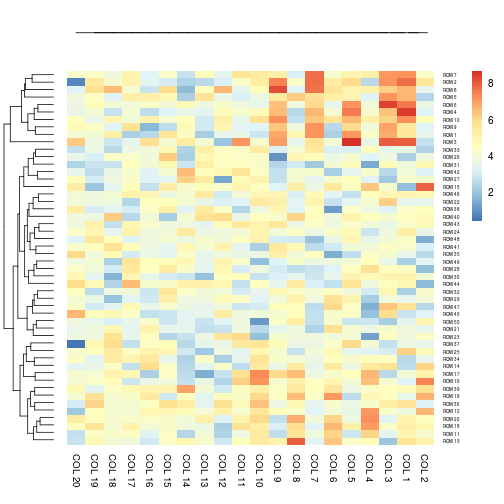

```r
aheatmap(x, Rowv = "man", Colv="binary")
```

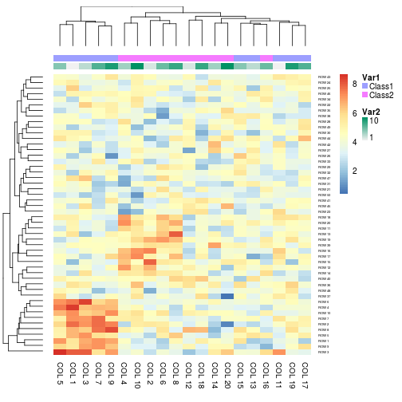

```r
# Generate column annotations
annotation = data.frame(Var1 = factor(1:p %% 2 == 0, labels = c("Class1", "Class2")), Var2 = 1:10)
aheatmap(x, annCol = annotation)
```

## Author

Original version of `pheatmap`: Raivo Kolde Enhancement into `aheatmap`: Renaud Gaujoux